# Netherlands: Parliamentary Elections, 1994-2012

Amber C. Kalb

3/25/2017

### The Rise of Right in Netherlands’ Parliament

In the postcolonial era, a national policy of multiculturalism was adopted by the Dutch government after waves of immigration from former colonies, Southern and Eastern European, as well as Middle-Eastern countries, increasingly diversified country’s population. While the 1990’s brought about an emphasis on assimilation policies, Netherlands’ national politics of multiculturalism became a point of contention and contestation after the murders of Pim Fortuyn (in 2002) and Theo van Gogh (in 2004). Further compounding xenophobic attitudes in the Netherlands, and the EU in general, was the subsequent Euro and Immigration Crises of 2009 and 2011, respectively. Economic and political turmoil further strained the government’s ability to financially and publicly support a national agenda centered on multicultural policies. This general trend in eroding popularity of leftist policies is illustrated in the chart below (Figure 1). The following graphs chart parliamentary elections in the Netherlands for almost two decades (1994-2012) by political alignment and party. For access to the original data see the [European Election Database](http://eed.nsd.uib.no/webview/index.jsp?study=http%3A%2F%2F129.177.90.166%3A80%2Fobj%2FfStudy%2Fnedpa2012&mode=cube&v=2&cube=http%3A%2F%2F129.177.90.166%3A80%2Fobj%2FfCube%2Fnedpa2012_C1&top=yes).

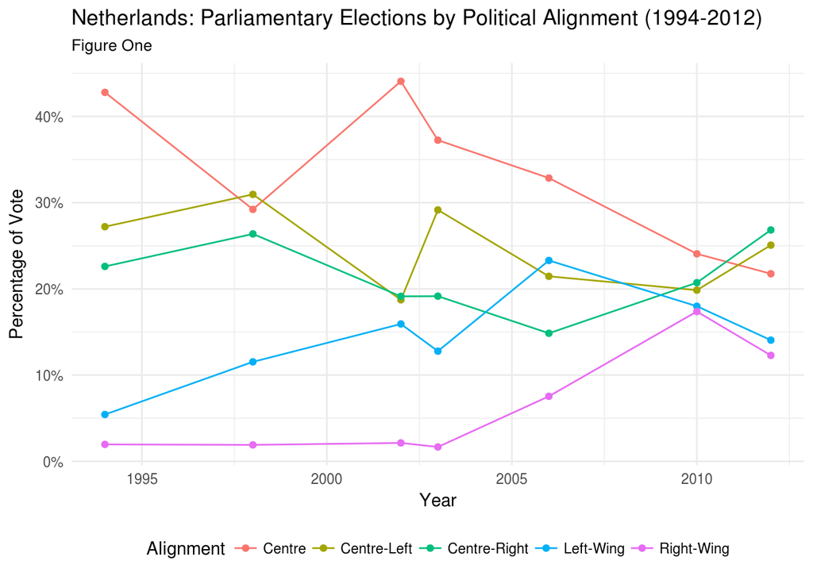

From 1994 through 2002, the majority of ballots cast during Dutch Parliamentary elections were overwhelmingly in support of moderate parties (centre, centre-left, centre-right). The 2006 elections mark a definite shift in voter trends away from moderate party alignment in favor of greater support of far-right and far-left factions. This same election year, representation of right-wing parties, by far, the least represented political alignment in the Dutch Parliament, gains a negotiable amount of seats. If we look at the graph below (Figure Two) we can see that the substantial increase in voter support of the far-right is likely due to the emergence of the People’s Freedom Party (PVV) in 2006.

### Party Politics

While the increasing polarization in ideological alignment through 2010 is not particularly surprising given economic, political and social climate in the Netherlands (see above), the election results in 2012 *are*. In terms of political alignment (Figure 1), the increasing popularity and predominance of the PVV and the VVD in recent Dutch Parliamentary elections suggest that voter trends would steadily increase, yet we see a marked hiccup in the 2012 elections. For less ambiguity, let’s turn to the graph below to locate voting shifts along party lines.

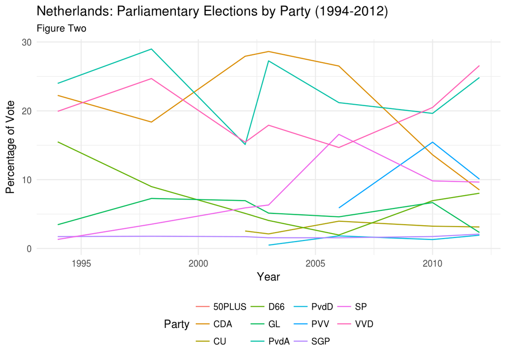

###### **Party Key:** People’s Party for Freedom and Democracy (VVD), Party for Freedom (PPV), Labour Party (PvdA), Socialist Party (SP), Christian Democratic Appeal (CDA), Democrats 66 (D66), Christian Union (CU), GreenLeft (GL), Reformed Political Party (SGP), Party for the Animals (PvdD), 50PLUS (50+)

The emergency election of 2012 occurred on account of the majority party’s (VVD) to garner support for austerity measures under the *Fiscal Compact*. Subsequently, the coalition government was dissolved and required a new election to reconstitute the House of Representatives. The party alignments was as such: VVD, CDA, D66 and GL in favor of austerity measures, while the opposition coalition consisted of PVV, CU and SP. The forced election was not a popular outcome among voters, and the PVV unwillingness to cooperate with the majority coalition was located as the primary cause. This was the first election in the PPV’s history that the party lost seats in the House.

### Concluding Thoughts

While the visualizations and the data do not address all voting trends shown, such as decreasing support for the GL, the data does bring to light party dynamics within Dutch politics beyond that of party alignment which can be often overlooked if you are coming from an American bipartisan perspective rather than a multi-party system represented in a coalition government. At the same time, coding for party alignment across multiple parties can elucidate overarching social and political trends among voters.

###### *Author’s Note*: This dataset would have better facilitated the analysis had it included the most recent data from the 2017 election, but the source of data transcription ([European Election Database](http://eed.nsd.uib.no/webview/index.jsp?study=http%3A%2F%2F129.177.90.166%3A80%2Fobj%2FfStudy%2Fnedpa2012&mode=cube&v=2&cube=http%3A%2F%2F129.177.90.166%3A80%2Fobj%2FfCube%2Fnedpa2012_C1&top=yes)) has not made this information available. In a future essay or analysis, I might transcribe another dataset inclusive of the most recent election data.